# final_R_reference

## Graphical Data Exploration

LET’S GRAPH :)

Scatter plot: Using the ginkgo data, create a scatter plot of max leaf depth (x) and max leaf width (y).

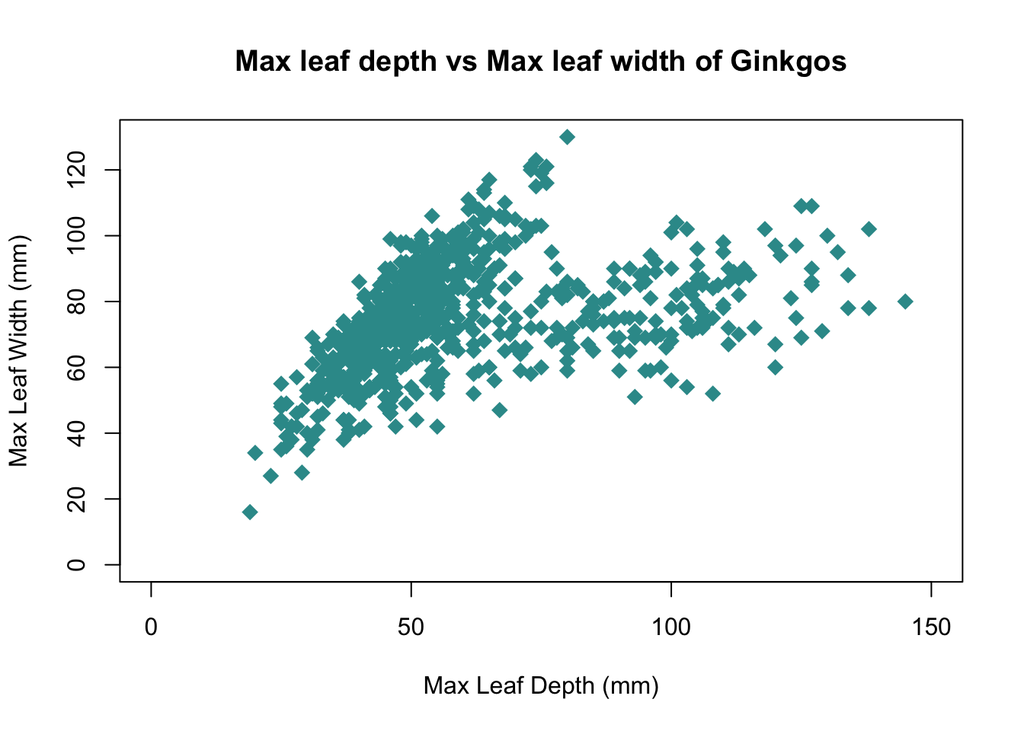

```r
# plot() is the generic function in r
# plot(y-axis~x-axis , data=)
#col = color of the plot symbol
#pch = plotting symbol
#cex = the number determines the size of text to symbols should be scaled
#main = title
#xlab = the name of the x-axis
#ylab = the name of the y-axis
#xlim = x-axis limits
#ylim = y-axis limits

plotleafxleaf<-plot(max_width~max_depth,data=ginkgo, main="Max leaf depth vs Max leaf width of Ginkgos",
   xlab="Max Leaf Depth (mm)", ylab="Max Leaf Width (mm)", pch=18, col="#339999", cex= 1.5, xlim=c(0,150), ylim=c(0,130) )
```

Making a Histogram

We use hist() to create a histogram of penguin flipper lengths

breaks = controlling the number of bins, bars or cells in a histogram

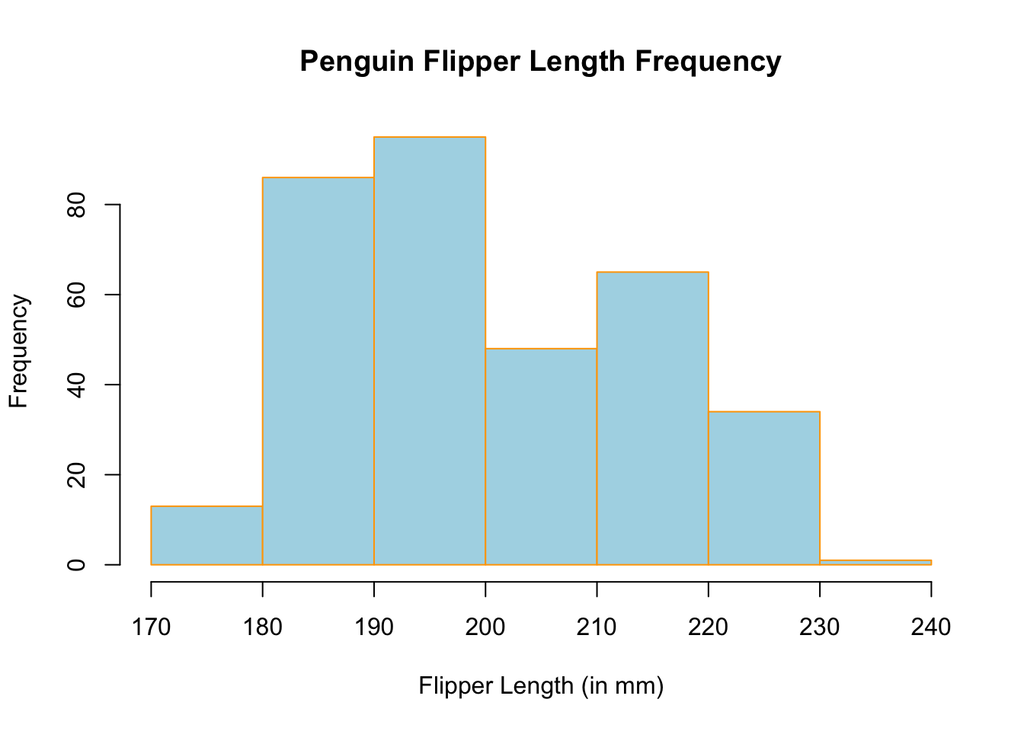

```r
hist(
  penguins$flipper_length_mm,
  main = "Penguin Flipper Length Frequency",
  col = "lightblue",
  border = "orange",
  xlab = "Flipper Length (in mm)",
  breaks= 8)
```

Making Boxplots

We start with a basic boxplot

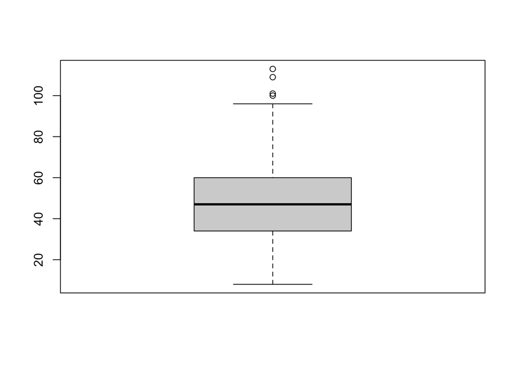

```r
boxplot(ginkgo$petiole_length)
```

Conditional box plot with a continous variable of leaf width conditioned on if seeds were present or not in the ginkgo data set

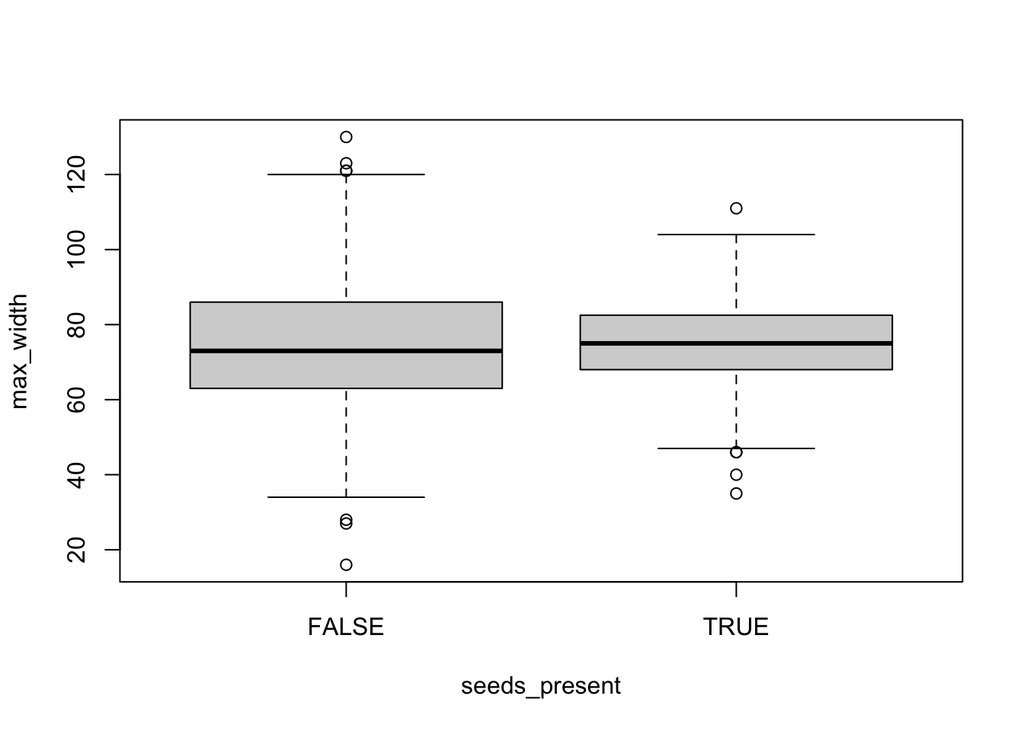

```r
boxplot(max_width ~ seeds_present, data = ginkgo)
```

Making a multipanel figure of 4 histograms We use par = creates multiple plots at once mfrow = define the multi plot set up with (row, column) number

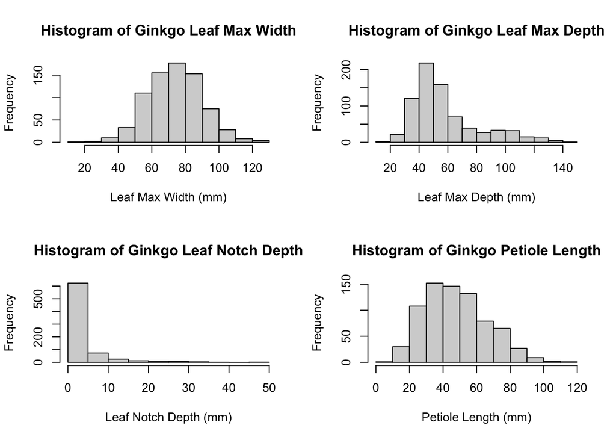

```r
par(mfrow = c(2, 2))
hist(
ginkgo$max_width,
main = "Histogram of Ginkgo Leaf Max Width",
xlab = "Leaf Max Width (mm)")
hist(
ginkgo$max_depth,
main = "Histogram of Ginkgo Leaf Max Depth",
xlab = "Leaf Max Depth (mm)")
hist(
ginkgo$notch_depth,
main = "Histogram of Ginkgo Leaf Notch Depth",
xlab = "Leaf Notch Depth (mm)"
)
hist(ginkgo$petiole_length,
main = "Histogram of Ginkgo Petiole Length",
xlab = "Petiole Length (mm)"
)
```

## Distribution Functions

dnorm(x, mean, standare deviation) is a function that gives you the value of the probability density function of a normal distribution according to your variables of choice

```r
dnorm(2,1.5,1)
```

```
## [1] 0.3520653
```

pnorm(x,mean, standard deviation) is a function that gives you the value of the cumulative density function of the normal distribution according to your variables of choice x= vector of quantiles

```r
pnorm(2,1.5,1)
```

```
## [1] 0.6914625
```

qnorm(x, mean, standard deviation) is a function on that gives you the inverse result of the cumulative density function (pnorm) x= the significance level to be used

```r
qnorm(.95,1.5,1)
```

```
## [1] 3.144854
```

dbinom(x_bin, size, probability) is like dnorm but returns the value of the probability density function for a binomial distribution

```r
dbinom(2,10,.6)
```

```
## [1] 0.01061683
```

pbinom(x_bin, size, probability) is like pnorm but returns value of the cumulative density function for a binomial distribution

```r
pbinom(2,10,.6)
```

```
## [1] 0.01229455
```

```r
dbinom(2,10,.6)
```

```
## [1] 0.01061683
```